# lab6-Chen

Weixuan Chen

2023-03-21

## Data

```r
# Download the data
d1=read.csv("http://faraway.neu.edu/biostats/lab6_dataset1.csv")
d2=read.csv("http://faraway.neu.edu/biostats/lab6_dataset2.csv")
```

## Task 1

## 1

```r
head(d1)
```

```
##     drug1   drug2     score
## 1 d1.ctrl d2.ctrl  130.7839
## 2 d1.ctrl d2.ctrl  294.0187
## 3 d1.ctrl d2.ctrl  106.0989
## 4 d1.ctrl d2.ctrl 1206.2610
## 5 d1.ctrl d2.ctrl  340.1912
## 6 d1.ctrl d2.ctrl  107.7196
```

```r
d1["drug1.binary"] <- as.numeric(factor(d1$drug1)) - 1
d1["drug2.binary"] <- as.numeric(factor(d1$drug2)) - 1
d1["log score"] <- log10(d1$score)
head(d1)
```

```
##     drug1   drug2     score drug1.binary drug2.binary log score
## 1 d1.ctrl d2.ctrl  130.7839            0            0  2.116554
## 2 d1.ctrl d2.ctrl  294.0187            0            0  2.468375
## 3 d1.ctrl d2.ctrl  106.0989            0            0  2.025711
## 4 d1.ctrl d2.ctrl 1206.2610            0            0  3.081441
## 5 d1.ctrl d2.ctrl  340.1912            0            0  2.531723
## 6 d1.ctrl d2.ctrl  107.7196            0            0  2.032295
```

```r
raw.aov <- aov(score ~ drug1.binary + drug2.binary + drug1.binary * drug2.binary, data = d1)
log10.aov <- aov(`log score` ~ drug1.binary + drug2.binary + drug1.binary * drug2.binary, data = d1)
```

```r
summary(raw.aov)
```

```
##                           Df  Sum Sq Mean Sq F value   Pr(>F)
## drug1.binary               1  498377  498377   4.224  0.04329 *
## drug2.binary               1 5016549 5016549  42.518 6.92e-09 ***
## drug1.binary:drug2.binary  1 1148512 1148512   9.734  0.00256 **
## Residuals                 76 8966901  117986
## ---
## Signif. codes:  0 '***' 0.001 '**' 0.01 '*' 0.05 '.' 0.1 ' ' 1
```

```r
summary(log10.aov)
```

```
##                           Df Sum Sq Mean Sq F value   Pr(>F)
## drug1.binary               1  0.316   0.316   2.283    0.135
## drug2.binary               1 12.216  12.216  88.344 2.30e-14 ***
## drug1.binary:drug2.binary  1  3.714   3.714  26.861 1.75e-06 ***
## Residuals                 76 10.509   0.138
## ---
## Signif. codes:  0 '***' 0.001 '**' 0.01 '*' 0.05 '.' 0.1 ' ' 1
```

Yes, the transformation changed the model fit by looking at the rediduals.

## 2

```r
raw.aov.resid <- resid(raw.aov)
log10.aov.resid <- resid(log10.aov)
```

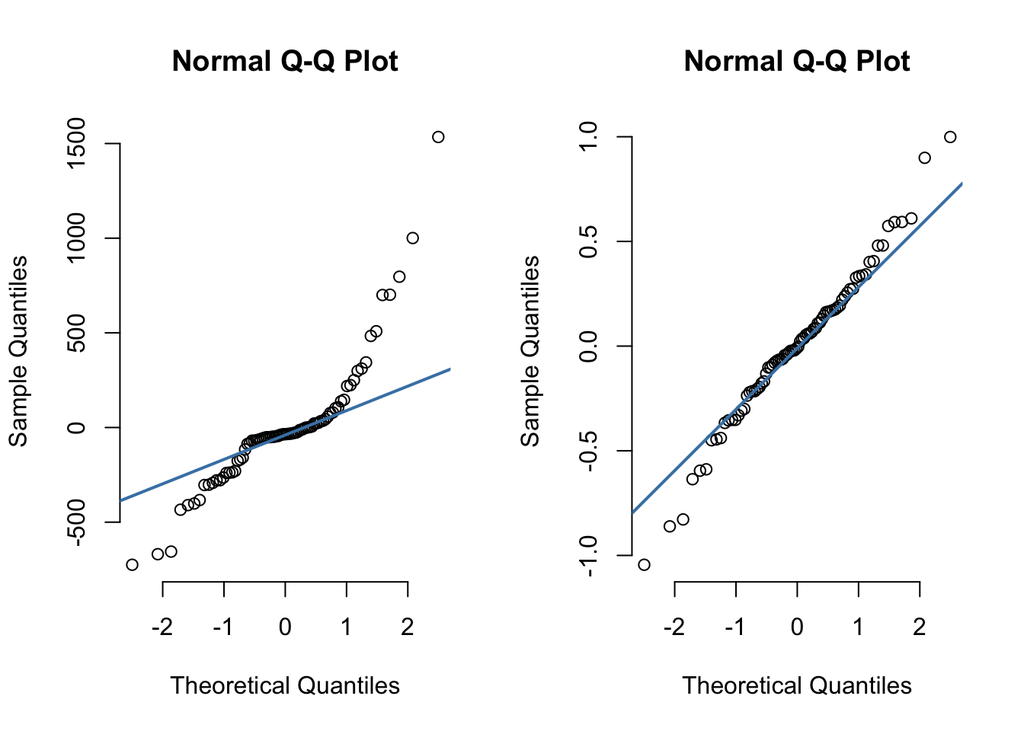

```r
par(mfrow=c(1,2))

qqnorm(raw.aov.resid, pch = 1, frame = FALSE)
qqline(raw.aov.resid, col = "steelblue", lwd = 2)

qqnorm(log10.aov.resid, pch = 1, frame = FALSE)
qqline(log10.aov.resid, col = "steelblue", lwd = 2)
```

From the QQ-plot, we can see the untransformed data does not follow the trend of qqline, but the transformed data does. Therefore, the transformation is needed and we should use transformed data.

## 3

From the ANOVA table of transformed data, we can observe that the p-value of drug1 is not significant, which we conclude that there is no significant different in means of drug1. For the other 2, the p-values are significant so we can conclude that there are differences between means in those groups.

## 4

```r
TukeyHSD(aov(`log score` ~ as.factor(drug1.binary) + as.factor(drug2.binary) + as.factor(drug1.binary) * as.factor(drug2.binary), data = d1))
```

```
##   Tukey multiple comparisons of means
##     95% family-wise confidence level
##
## Fit: aov(formula = `log score` ~ as.factor(drug1.binary) + as.factor(drug2.binary) + as.factor(drug1.binary) * as.factor(drug2.binary), data = d1)
##
## $`as.factor(drug1.binary)`
##           diff       lwr        upr     p adj
## 1-0 -0.1256276 -0.291231 0.03997577 0.1349625
##
## $`as.factor(drug2.binary)`
##          diff        lwr        upr p adj
## 1-0 -0.781521 -0.9471244 -0.6159177     0
##
## $`as.factor(drug1.binary):as.factor(drug2.binary)`
##               diff          lwr         upr     p adj
## 1:0-0:0  0.3053110 -0.003571068  0.61419311 0.0538820
## 0:1-0:0 -0.3505824 -0.659464491 -0.04170031 0.0197271
## 1:1-0:0 -0.9071487 -1.216030744 -0.59826657 0.0000000
## 0:1-1:0 -0.6558934 -0.964775512 -0.34701133 0.0000021
## 1:1-1:0 -1.2124597 -1.521341765 -0.90357759 0.0000000
## 1:1-0:1 -0.5565663 -0.865448342 -0.24768416 0.0000585
```

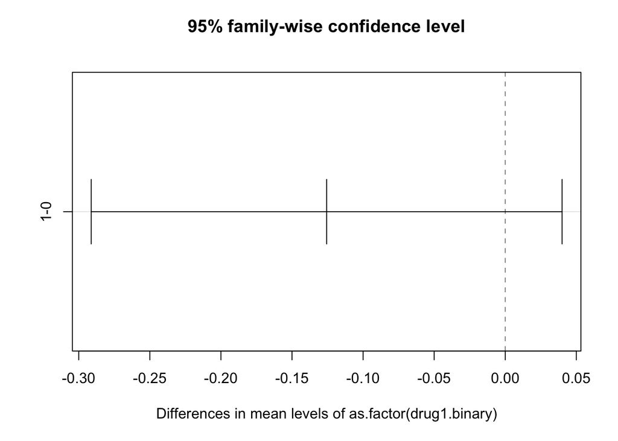

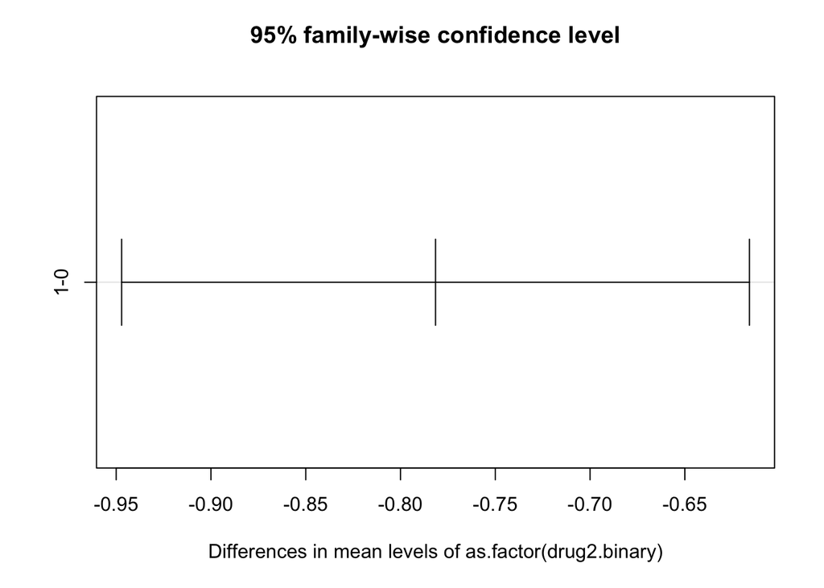

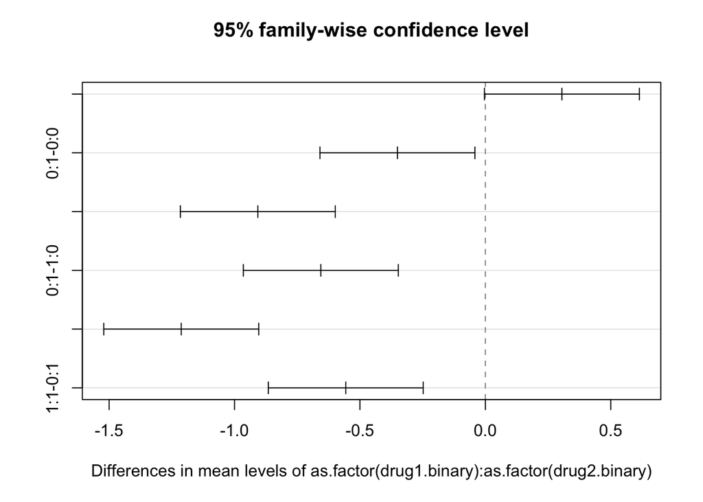

```r
plot(TukeyHSD(aov(`log score` ~ as.factor(drug1.binary) + as.factor(drug2.binary) + as.factor(drug1.binary) * as.factor(drug2.binary), data = d1)))
```

## 6

```r
d1["drug1:drug2"] <- d1$drug1.binary*d1$drug2.binary
d1
```

```
##      drug1   drug2       score drug1.binary drug2.binary log score drug1:drug2
## 1  d1.ctrl d2.ctrl  130.783880            0            0 2.1165542           0
## 2  d1.ctrl d2.ctrl  294.018686            0            0 2.4683749           0
## 3  d1.ctrl d2.ctrl  106.098869            0            0 2.0257108           0
## 4  d1.ctrl d2.ctrl 1206.261037            0            0 3.0814413           0
## 5  d1.ctrl d2.ctrl  340.191186            0            0 2.5317231           0
## 6  d1.ctrl d2.ctrl  107.719607            0            0 2.0322948           0
## 7  d1.ctrl d2.ctrl  398.389055            0            0 2.6003074           0
## 8  d1.ctrl d2.ctrl  512.000041            0            0 2.7092700           0
## 9  d1.ctrl d2.ctrl  435.189406            0            0 2.6386783           0
## 10 d1.ctrl d2.ctrl  180.298104            0            0 2.2559912           0
## 11 d1.ctrl d2.ctrl 1109.629182            0            0 3.0451779           0
## 12 d1.ctrl d2.ctrl  361.348634            0            0 2.5579264           0
## 13 d1.ctrl d2.ctrl  131.467467            0            0 2.1188183           0
## 14 d1.ctrl d2.ctrl   26.717001            0            0 1.4267877           0
```

[output cut: 66 more lines]

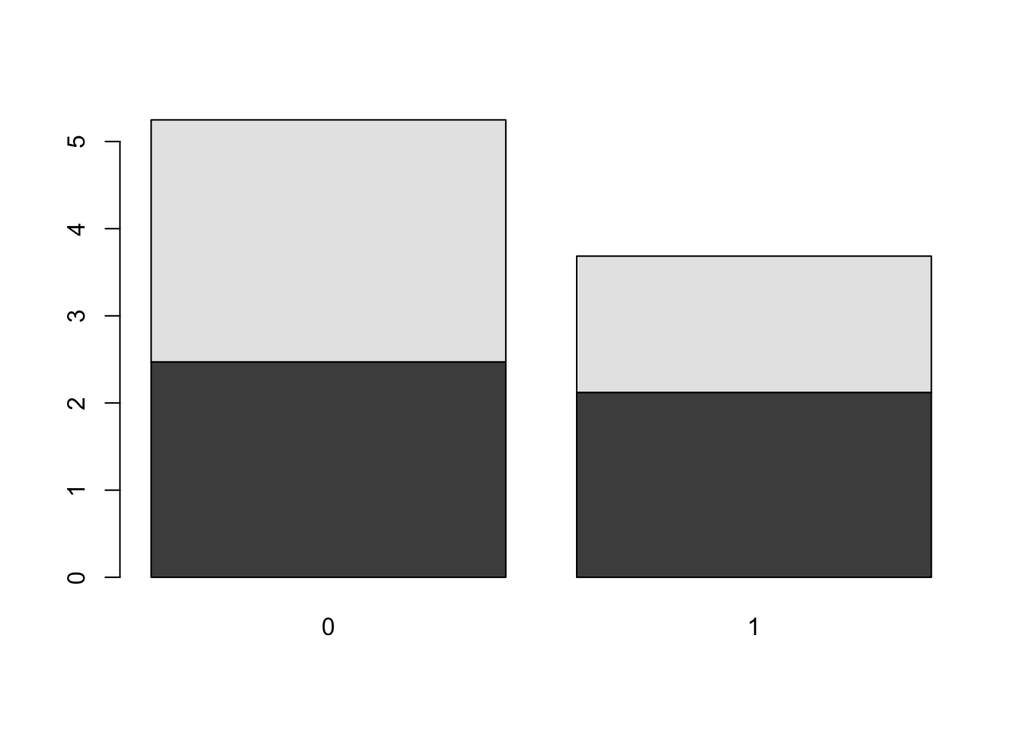

```r
require(multcompView, quietly=TRUE)
# Compute the mean and std error of each group. You can do this a different way, if you like
means=tapply(d1$`log score`, list(d1$drug1.binary, d1$drug2.binary), mean)
stderrs=tapply(d1$`log score`, list(d1$drug1.binary, d1$drug2.binary), sd)
# Assign a label to each bar. You will need to insert the name of your model object
#labels=multcompLetters(d1$`drug1:drug2`[, 'p adj'])$
# Order the labels
#labels=labels[order(names(labels))]
# Plot the figure
bp=barplot(means)
```

## 7

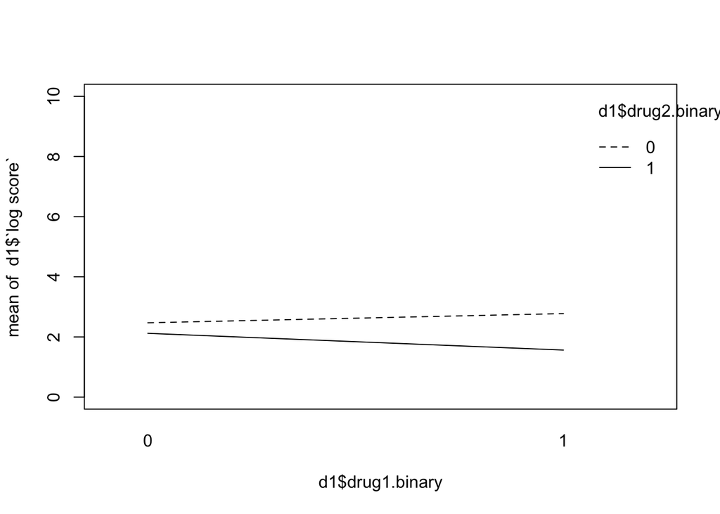

```r
interaction.plot(d1$drug1.binary, d1$drug2.binary, d1$`log score`,ylim = c(0, 10))
```

I prefer interaction.plot. It is more straightforward to show the difference in interaction. We can see the slope starts to change from 0 to 1 by the direction of x-axis. This means the difference starts to appear.

## 8

By the plot and the result, I would say the interaction of these two drugs have the most effective performance on the disease, because not only does the change in means appear but also does the decrease in means of scores appear. The interaction of drug 1 and 2 reduces the viral load the most.

## Task 2

## 1

```r
d2
```

```
##       drug1   drug2       score    sex
## 1   d1.ctrl d2.ctrl   99.791744   male
## 2   d1.ctrl d2.ctrl  294.373446   male
## 3   d1.ctrl d2.ctrl 1197.325180   male
## 4   d1.ctrl d2.ctrl   79.013943   male
## 5   d1.ctrl d2.ctrl  225.822263   male
## 6   d1.ctrl d2.ctrl  279.337376   male
## 7   d1.ctrl d2.ctrl  496.684358   male
## 8   d1.ctrl d2.ctrl  192.539625   male
## 9   d1.ctrl d2.ctrl 1780.187432   male
## 10  d1.ctrl d2.ctrl  212.983136   male
## 11  d1.ctrl d2.ctrl  371.537853   male
## 12  d1.ctrl d2.ctrl  653.114708   male
## 13  d1.ctrl d2.ctrl  165.224416   male
## 14  d1.ctrl d2.ctrl   86.516143   male
```

[output cut: 146 more lines]

```r
d2["drug1.binary"] <- as.numeric(factor(d2$drug1)) - 1
d2["drug2.binary"] <- as.numeric(factor(d2$drug2)) - 1
d2["sex.binary"] <- as.numeric(factor(d2$sex)) - 1
d2["log score"] <- log10(d2$score)
```

```r
d2.aov <- aov(`log score` ~  drug1.binary * drug2.binary * sex.binary, data=d2)
summary(d2.aov)
```

```
##                                       Df Sum Sq Mean Sq F value   Pr(>F)
## drug1.binary                           1  0.194   0.194   1.049  0.30741
## drug2.binary                           1 15.930  15.930  86.086  < 2e-16 ***
## sex.binary                             1  1.587   1.587   8.576  0.00393 **
## drug1.binary:drug2.binary              1  1.039   1.039   5.613  0.01909 *
## drug1.binary:sex.binary                1  0.480   0.480   2.593  0.10938
## drug2.binary:sex.binary                1  1.902   1.902  10.278  0.00164 **
## drug1.binary:drug2.binary:sex.binary   1  4.197   4.197  22.679 4.43e-06 ***
## Residuals                            152 28.126   0.185
## ---
## Signif. codes:  0 '***' 0.001 '**' 0.01 '*' 0.05 '.' 0.1 ' ' 1
```

We can see the drug1 and drug1:sex are not significant at 0.05 level, while others are. We can conclude that the means in these two groups are not significantly different while other are.

## 2

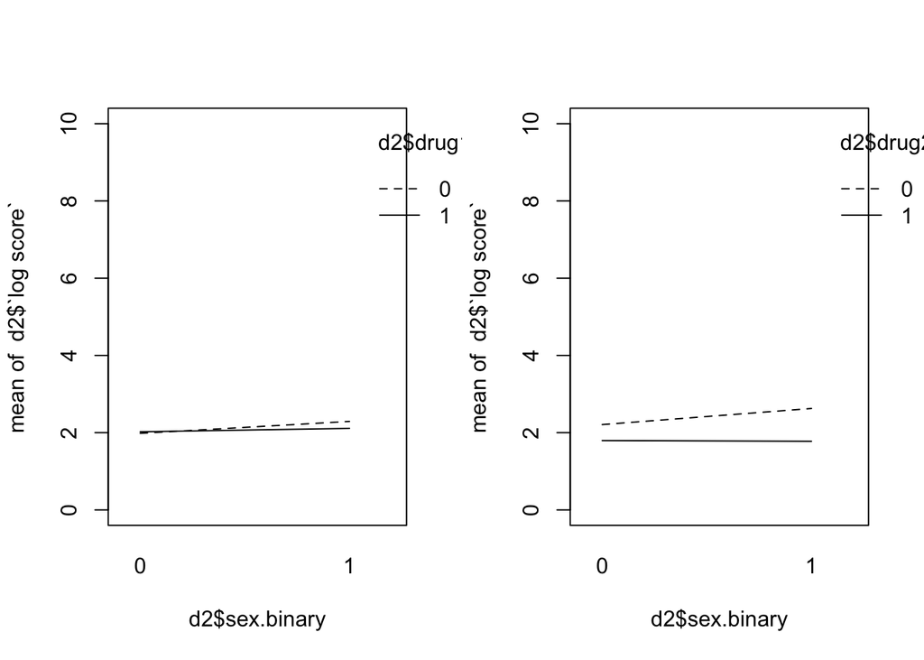

```r
par(mfrow=c(1,2))
interaction.plot(d2$sex.binary, d2$drug1.binary, d2$`log score`,ylim = c(0, 10))
interaction.plot(d2$sex.binary, d2$drug2.binary, d2$`log score`,ylim = c(0, 10))
```

## 3

We can look at the slope of these two plots. In plot 1, the slopes do not have significant difference. This means the mean in scores does not have significant differences for sex and each group of drug1. But this situation changes for sex and drug 2, where we can observe a significant changes in slopes. This means the treatment has differences in means compared to the control group.

## 4

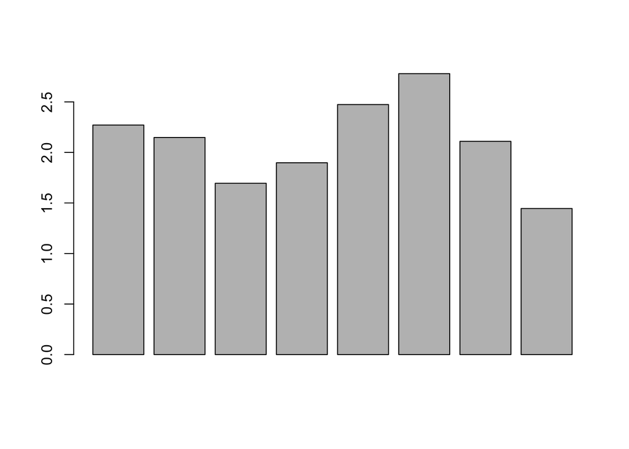

```r
# Compute mean and standard error for each group
means=aggregate(`log score` ~ drug1.binary + drug2.binary + sex.binary, FUN=mean, data=d2)
stderrs=aggregate(`log score` ~ drug1.binary + drug2.binary + sex.binary,
sd, data=d2)
# Perform multiple comparisons
d2.mod.aov.tukey=TukeyHSD(aov(`log score` ~ as.factor(drug1.binary) * as.factor(drug2.binary) * as.factor(sex.binary), data = d2))
# Plot bars
bp=barplot(means$`log score`)
```

```r
bp
```

```
##      [,1]
## [1,]  0.7
## [2,]  1.9
## [3,]  3.1
## [4,]  4.3
## [5,]  5.5
## [6,]  6.7
## [7,]  7.9
## [8,]  9.1
```

```r
d2.mod.aov.tukey
```

```
##   Tukey multiple comparisons of means
##     95% family-wise confidence level
##
## Fit: aov(formula = `log score` ~ as.factor(drug1.binary) * as.factor(drug2.binary) * as.factor(sex.binary), data = d2)
##
## $`as.factor(drug1.binary)`
##            diff        lwr        upr     p adj
## 1-0 -0.06965517 -0.2040323 0.06472199 0.3074093
##
## $`as.factor(drug2.binary)`
##           diff       lwr        upr p adj
## 1-0 -0.6310608 -0.765438 -0.4966836     0
##
## $`as.factor(sex.binary)`
##          diff        lwr       upr     p adj
## 1-0 0.1991764 0.06479926 0.3335536 0.0039316
##
## $`as.factor(drug1.binary):as.factor(drug2.binary)`
##                diff        lwr         upr     p adj
## 1:0-0:0  0.09147952 -0.1583860  0.34134503 0.7772743
## 0:1-0:0 -0.46992612 -0.7197916 -0.22006060 0.0000153
## 1:1-0:0 -0.70071598 -0.9505815 -0.45085047 0.0000000
## 0:1-1:0 -0.56140563 -0.8112711 -0.31154012 0.0000002
## 1:1-1:0 -0.79219550 -1.0420610 -0.54232999 0.0000000
## 1:1-0:1 -0.23078987 -0.4806554  0.01907564 0.0815022
##
## $`as.factor(drug1.binary):as.factor(sex.binary)`
##                diff         lwr        upr     p adj
## 1:0-0:0  0.03987710 -0.20998841 0.28974261 0.9759054
## 0:1-0:0  0.30870870  0.05884319 0.55857421 0.0087265
## 1:1-0:0  0.12952125 -0.12034426 0.37938676 0.5348692
## 0:1-1:0  0.26883160  0.01896609 0.51869711 0.0295965
## 1:1-1:0  0.08964415 -0.16022136 0.33950966 0.7877383
## 1:1-0:1 -0.17918745 -0.42905296 0.07067806 0.2484803
##
## $`as.factor(drug2.binary):as.factor(sex.binary)`
##                diff        lwr        upr     p adj
## 1:0-0:0 -0.41300636 -0.6628719 -0.1631408 0.0001815
## 0:1-0:0  0.41723087  0.1673654  0.6670964 0.0001523
## 1:1-0:0 -0.43188438 -0.6817499 -0.1820189 0.0000820
```

[output cut: 19 more lines]

```
## 1:1:0-0:1:0  0.20265018 -0.215455205  0.62075557 0.8118501
## 0:0:1-0:1:0  0.77863481  0.360529426  1.19674020 0.0000015
## 1:0:1-0:1:0  1.08448983  0.666384446  1.50259522 0.0000000
## 0:1:1-0:1:0  0.41456202 -0.003543361  0.83266741 0.0537436
## 1:1:1-0:1:0 -0.24966789 -0.667773276  0.16843750 0.5971080
## 0:0:1-1:1:0  0.57598463  0.157879245  0.99409002 0.0010122
## 1:0:1-1:1:0  0.88183965  0.463734265  1.29994504 0.0000000
## 0:1:1-1:1:0  0.21191184 -0.206193543  0.63001723 0.7743766
## 1:1:1-1:1:0 -0.45231807 -0.870423458 -0.03421269 0.0239730
## 1:0:1-0:0:1  0.30585502 -0.112250366  0.72396041 0.3293164
## 0:1:1-0:0:1 -0.36407279 -0.782178174  0.05403260 0.1379763
## 1:1:1-0:0:1 -1.02830270 -1.446408089 -0.61019732 0.0000000
## 0:1:1-1:0:1 -0.66992781 -1.088033194 -0.25182242 0.0000587
## 1:1:1-1:0:1 -1.33415772 -1.752263109 -0.91605234 0.0000000
## 1:1:1-0:1:1 -0.66422991 -1.082335301 -0.24612453 0.0000704
```

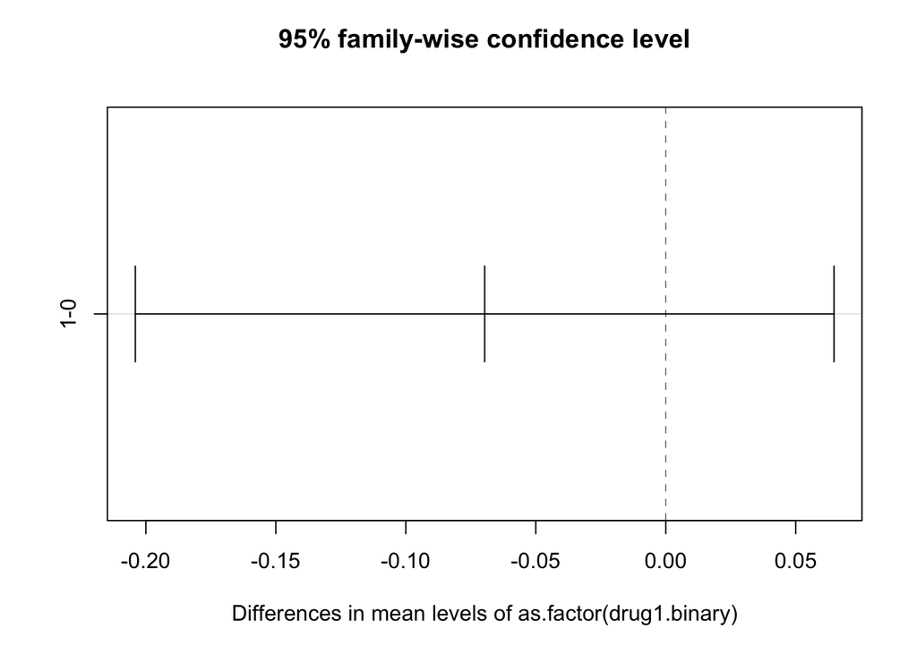

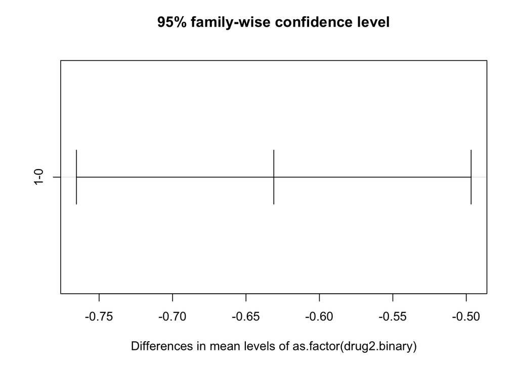

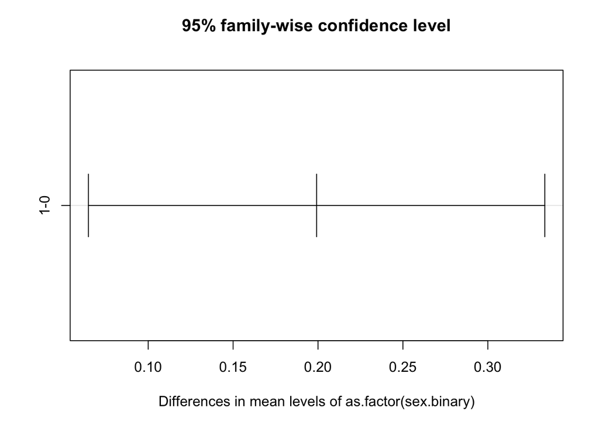

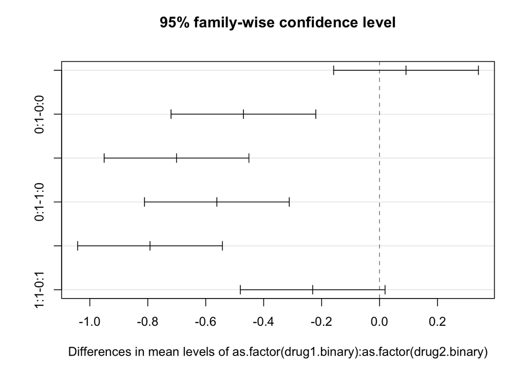

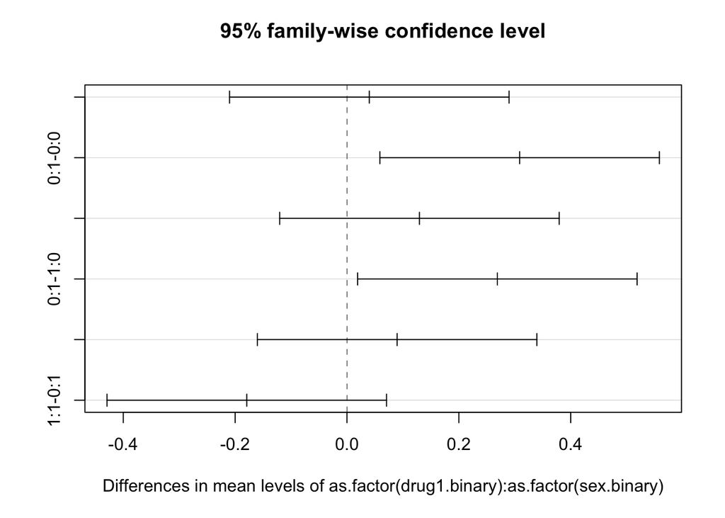

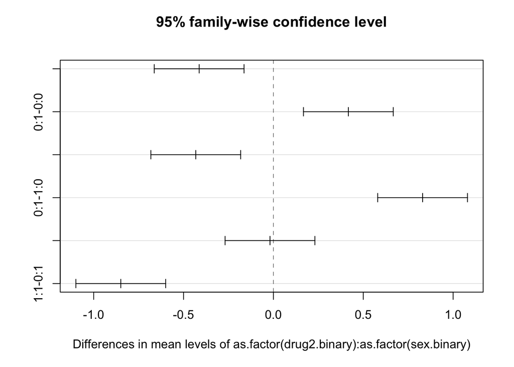

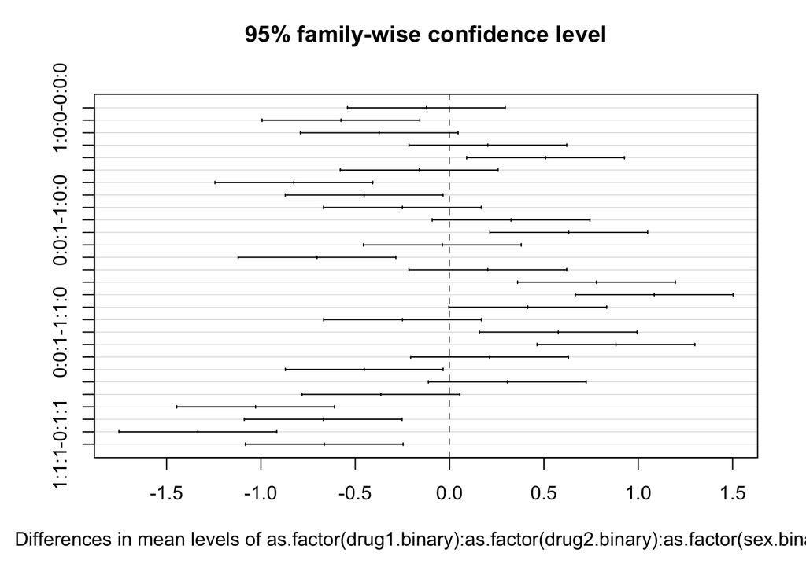

```r
plot(TukeyHSD(aov(`log score` ~ as.factor(drug1.binary) * as.factor(drug2.binary) * as.factor(sex.binary), data = d2)))
```